# ProbaV

## Plot the metrics

Once the function has successfully passed, we can see the output! The output is a brick of rasters that store the model coefficients (or metrics) applied in the probaV::getHarmMetricsSpatial function. Thus, the amount of bands returned (as raster layers) depends on the chosen 'order' in the probaV::getHarmMetricsSpatial. Due to the parallelization of the function, the names of the output (brick) get lost, and the chronological order along with it.

Since the probaV::getHarmMetricsSpatial function uses the probaV::getHarmMetrics function, but applies it to a raster, we can see the names of the metrics by evaluating our previously probaV::getHarmMetrics section.

Lets plot the first 6 layers from the created metrics brick. As can be observed, the names are lost of the bands, and the raster values have been scaled by the selected 'scale_f' parameter in the probaV::getHarmMetricsSpatial function.

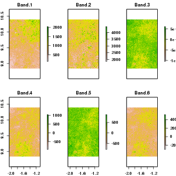

```r
# metrics info
b_metrics <- brick(out_name)
# plotting metrics
sub_plot <- subset(b_metrics, 1:6)
plot(sub_plot)
```

## Classification process

Lets create a land cover classification dataset from our returned metrics!

In order for us to classify our region of interest, we need a set of reference data. Lets read a .csv file from a github repository that contains reference data from a subset of North-West Africa. However, you can create or use a different reference dataset for a different region. The next section downloads a .csv file and assigns coordinates and projection system to the file. We will then plot one of our metrics bands with the reference data.

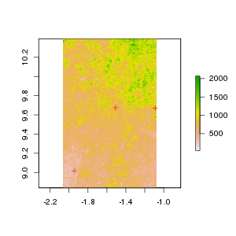

```r
csv <- getURL("https://raw.githubusercontent.com/JornDallinga/JornDallinga.github.io/master/ref/ref_JD.csv")
pts <- read.csv(text = csv)

coordinates(pts) <- ~X+Y

# add projection
projection(pts) <- '+proj=longlat +datum=WGS84 +no_defs +ellps=WGS84 +towgs84=0,0,0'

# copy dataset
pnt_JD <- pts

# crop dataset
pnt_JD <- crop(pnt_JD, b_metrics)

# plot an image with the point reference data.
plot(b_metrics$Band.1)
plot(pnt_JD, add = T, col = 'red')
```

Here, we extract the cell values per reference point and create a merged dataframe. This dataframe will serve as our reference data, where each band value represents the value that intersects with a certain reference point. The output of the parallel processing section below, results in a spatialdataframe with the number of rows equal to the amount of reference points.

```r
# ----------------------- extract per tile ------------------#
tiles <- c("X17Y06") # ..., "X17Y06", "X18Y06", "X19Y06")

# run parallel processing on tiles
registerDoParallel(min(4, length(tiles)))
df_covs_JD <- foreach(tile=tiles, .combine=rbind, .inorder = T) %dopar% {
  print(tile)
  b_metrics <- b_metrics
  print("loaded")
  df_metrics_tile  <- extract(b_metrics, pnt_JD, cellnumbers=T, df=T)
  df_metrics_tile <- cbind(tile=rep(tile, nrow(df_metrics_tile)), df_metrics_tile)
  df_metrics_tile  <- na.exclude(df_metrics_tile)
  df_covs_tile <- df_metrics_tile
}
```

```r
## [1] "X17Y06"
## [1] "loaded"
```

```r
# call data frame
df_covs_JD
```

```r
##     tile ID   cells Band.1 Band.2  Band.3 Band.4 Band.5 Band.6 Band.7
## 1 X17Y06  1  727796    657   2624 2244297   -438    437  -1112     14
## 2 X17Y06  2  722389    840   2988  128252   -209    528    -63     15
## 3 X17Y06  3 1382958    320   2592  911440   -224    407   -451     15
##   Band.8  Band.9 Band.10 Band.11 Band.12 Band.13 Band.14 Band.15 Band.16
## 1     69 -100343      10     -17      50    4069    8399 5239215   -1251
## 2     62  -30379       4     -18      15    4814    9404  137746    -434
## 3     85  -62234       2     -28      31    3668    7568 5213221   -1033
##   Band.17 Band.18
## 1    1263   -2596
## 2    1579     -65
## 3    1571   -2583
```

Check if n reference points equal n rows of our output spatialdataframe

```r
# Check if n == nrow
nrow(df_covs_JD) == nrow(pnt_JD)
```

```r
## [1] TRUE
```

Lets add the the reference class 'Code' to the our dataframe.

```r
df_ref_JD <- pnt_JD@data[df_covs_JD$ID,]
df_model_JD <- cbind(Code=df_ref_JD$Code, df_covs_JD)
df_model_JD
```

```r
##   Code   tile ID   cells Band.1 Band.2  Band.3 Band.4 Band.5 Band.6 Band.7
## 1    5 X17Y06  1  727796    657   2624 2244297   -438    437  -1112     14
## 2    2 X17Y06  2  722389    840   2988  128252   -209    528    -63     15
## 3    1 X17Y06  3 1382958    320   2592  911440   -224    407   -451     15
##   Band.8  Band.9 Band.10 Band.11 Band.12 Band.13 Band.14 Band.15 Band.16
## 1     69 -100343      10     -17      50    4069    8399 5239215   -1251
## 2     62  -30379       4     -18      15    4814    9404  137746    -434
## 3     85  -62234       2     -28      31    3668    7568 5213221   -1033
##   Band.17 Band.18
## 1    1263   -2596
## 2    1579     -65
## 3    1571   -2583
```

```r
# good to save this!
```

```r
# exclude some classes
df_model_JD <- subset(df_model_JD, Code <= 5)

# exclude NAs
cc <- complete.cases(df_model_JD)

# assign names to classes
df_model_JD$LC[df_model_JD$Code == 1] <- "Forest"
df_model_JD$LC[df_model_JD$Code == 2] <- "Shrubland"
df_model_JD$LC[df_model_JD$Code == 3] <- "Grassland"
df_model_JD$LC[df_model_JD$Code == 4] <- "Cropland"
df_model_JD$LC[df_model_JD$Code == 5] <- "Bare"

# convert to factor
df_model_JD$LC <- as.factor(df_model_JD$LC)

# only complete cases
print("The amount of reference points per class")
```

```r
## [1] "The amount of reference points per class"
```

```r
table(df_model_JD$LC[cc])
```

```r
##
##      Bare    Forest Shrubland
##         1         1         1
```

"Ranger is a fast implementation of random forest (Breiman 2001) or recursive partitioning, particularly suited for high dimensional data. Classification, regression, probability estimation and survival forests are supported. Classification and regression forests are implemented as in the original Random Forest (Breiman 2001), survival forests as in Random Survival Forests (Ishwaran et al. 2008). For probability estimation forests see Malley et al. (2012)." [source](https://github.com/imbs-hl/ranger).

The following block runs the ranger function on our training data (df\_model_JD) and writes the output ranger model to a RDS file.

```r
# run ranger on Land cover classification
# exclude the first 4 columns of the df_model_JD by df_model_JD[cc, -(1:4)]
ra_JD <- ranger(LC ~ ., df_model_JD[cc, -(1:4)], num.trees=500, write.forest=T,
                  probability = F, num.threads=10, verbose=T, importance = "impurity")

# save the ranger model
dir.create('data',showWarnings = F)
dir.create('data/models',showWarnings = F)
saveRDS(ra_JD, "data/models/ra_JD_merge5_x16.rds")
print(ra_JD)
```

```r
## Ranger result
##
## Call:
##  ranger(LC ~ ., df_model_JD[cc, -(1:4)], num.trees = 500, write.forest = T,      probability = F, num.threads = 10, verbose = T, importance = "impurity")
##
## Type:                             Classification
## Number of trees:                  500
## Sample size:                      3
## Number of independent variables:  18
## Mtry:                             4
## Target node size:                 1
## Variable importance mode:         impurity
## OOB prediction error:             100.00 %
```

Now the final step of this tutorial! Here we run the probaV::mcPredictSpatial function that classifies our metrics based on the ranger model we created. We read back our created ranger model from the directory.

```r
# ------------- predict -------------------------------------------
dir.create('rsdata/ProbaV/results',showWarnings = F)

# read the ranger model
model <- readRDS("data/models/ra_JD_merge5_x16.rds")

# assign the tile
tiles <- c("X17Y06")

# set the output filename of the prediction results
out_name <- paste0(getwd(), "/rsdata/ProbaV/results/pred_JD_")

for (tile in tiles){
  print(paste0("--------------", tile, "-------------------"))
  b_metrics <- b_metrics
  print("---predict--------------")

  out_name <- paste0(out_name, tile,  ".tif")

  pred_JD <- mcPredictSpatial(model, b_metrics, b_clumps=NULL, df_clumps = NULL, type='response',
                                mc.cores = 10, ranger_threads = 1, minrows = 12, logfile = logfile,
                                datatype ="INT1U", of ="GTiff", out_name = out_name)

  print(pred_JD)
}
```

```r
## [1] "--------------X17Y06-------------------"
## [1] "---predict--------------"
## list()
## [1] "/home/JD/R_Projects/JornDallinga.github.io/rsdata/ProbaV/results/pred_JD_X17Y06.tif"
## class       : RasterBrick
## dimensions  : 1566, 997, 1561302, 1  (nrow, ncol, ncell, nlayers)
## resolution  : 0.0009920635, 0.0009920635  (x, y)
## extent      : -2.064549, -1.075462, 8.839789, 10.39336  (xmin, xmax, ymin, ymax)
## coord. ref. : +proj=longlat +datum=WGS84 +no_defs +ellps=WGS84 +towgs84=0,0,0
## data source : /home/JD/R_Projects/JornDallinga.github.io/rsdata/ProbaV/results/pred_JD_X17Y06.tif
## names       : pred_JD_X17Y06
## min values  :              0
## max values  :            255
```

Now lets check our results! Below a land-cover classified image on our subset! NOTE: Be sure to add and/or change the colors based on the amount of classes you created!

```r
r <- raster(paste0(getwd(), "/rsdata/ProbaV/results/pred_JD_", tile,  ".tif"))
r <- as.factor(r)
rat <- levels(r)[[1]]
rat[["landcover"]] <- levels(ra_JD$predictions) # double check this
levels(r) <- rat

# add/change colours if you have more legend items. The colours should be defined in the order as given by the 'rat' variable.
rat # # The first row of 'rat' (bare) equals the first colour below (chocolate4).
```

```r
##   ID landcover
## 1  1      Bare
## 2  2    Forest
## 3  3 Shrubland
```

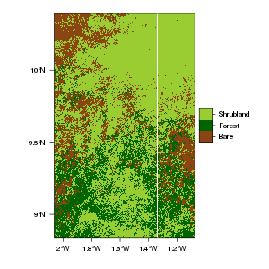

```r
my_col = c('chocolate4','darkgreen','yellowgreen')

# Plot
levelplot(r, col.regions=my_col, xlab="", ylab="")
```

And lets plot the full tile we have been processing in the tutorial. Below the our tile with the reference points, followed by a classified image.

```r
##   ID landcover
## 1  1      Bare
## 2  2  Cropland
## 3  3    Forest
## 4  4 Grassland
## 5  5 Shrubland
```

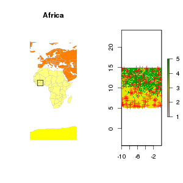

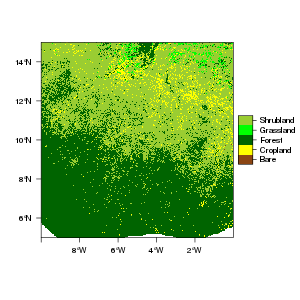

Congrats! Now have fun applying this tutorial on your region of interest! Keep in mind that there are several limitations on the cloud filter section. The discussed approach is less suited to distinguish ice clouds from snow/ice!

This tutorial has been tested on the S5 (5-day) 100m resolution product of ProbaV. It might return unexpected results or errors if attempted on different data sets, and has not been tested yet on other sensors, and products of ProbaV.

The tutorial and data availability is still under construction, so please report any errors or anomalies on the [github account](https://github.com/JornDallinga/JornDallinga.github.io) of this tutorial or directly on the [probaV package](https://github.com/johanez/probaV).

### Acknowledgements

The tutorial and related research activities have been done within the framework of the PROBA-V MEP project and with support and funding of the [ESA](https://proba-v-mep.esa.int/).

[creative commens](https://creativecommons.org/licenses/by-sa/4.0/)

Styled with knitrBootstrap